# Analysis of Alpha and Beta diversity in R - rarefaction, alpha- and beta- diversity and vizualizations Rasmussen_2017_V1V3_single_only-psyllium

#### To check that the rarefaction worked out check the number of reads per sample:

```r
sort(rowSums(SV.table.rarefied))
```

```
#> SRR5504436 SRR5504425 SRR5504432 SRR5504433 SRR5504422 SRR5504429 SRR5504426
#>          2       1192       1193       1193       1194       1194       1195
#> SRR5504431 SRR5504440 SRR5504444 SRR5504424 SRR5504428 SRR5504439 SRR5504423
#>       1195       1195       1195       1196       1196       1196       1197
#> SRR5504427 SRR5504437 SRR5504430 SRR5504434 SRR5504435 SRR5504442 SRR5504438
#>       1197       1197       1198       1198       1198       1199       1200
#> SRR5504441 SRR5504443 SRR5504445
#>       1201       1201       1202
```

#### Drop those samples that had under rarefaction threshold (samples SRR5504436):

#https://www.datasciencemadesimple.com/delete-or-drop-rows-in-r-with-conditions-2/

```r
 SV.table.rarefied <- SV.table.rarefied[!(row.names(SV.table.rarefied) %in% c('SRR5504436')), ]

sort(rowSums(SV.table.rarefied))
```

```
#> SRR5504425 SRR5504432 SRR5504433 SRR5504422 SRR5504429 SRR5504426 SRR5504431
#>       1192       1193       1193       1194       1194       1195       1195
#> SRR5504440 SRR5504444 SRR5504424 SRR5504428 SRR5504439 SRR5504423 SRR5504427
#>       1195       1195       1196       1196       1196       1197       1197
#> SRR5504437 SRR5504430 SRR5504434 SRR5504435 SRR5504442 SRR5504438 SRR5504441
#>       1197       1198       1198       1198       1199       1200       1201
#> SRR5504443 SRR5504445
#>       1201       1202
```

#### Results:

We dropped sample SRR5504436

#### Save filtered & rarefied OTU SV.table.rarefied:

```r
setwd("/Volumes/Seagate/Meta_analysis/Alpha_Beta_analysis/Rasmussen_2017_V1V3/psyllium/Output_files")

write.table(SV.table.rarefied, file = "3.psyllium_OTU_filtered_rarefied_1197_ROUNDED.tsv", sep = "\t", row.names = TRUE, col.names = NA)
```

## __________ Alpha-diversity Analyses_________

#### Calculate different alpha diversity metrics (Shannon, Richness, Simpson):

```r
shannon <- as.data.frame(diversity(SV.table.rarefied, index = "shannon"))
names(shannon) <- c("Shannon")
richness <- as.data.frame(apply(SV.table.rarefied[,]>0, 1, sum))
names(richness) <- c("Richness")
simpson <- as.data.frame(diversity(SV.table.rarefied, index = "simpson"))
names(simpson) <- c("Simpson")
```

#### Merge alpha-diversity metrics together:

```r
tmp1 <- merge(richness, shannon, by.x = "row.names", by.y = "row.names")
all.alpha <- merge(tmp1, simpson, by.x = "Row.names", by.y = "row.names")
names(all.alpha) <- c("SampleID", names(all.alpha)[2:length(names(all.alpha))])
```

#### Merge metadata to aplha metrics so you can create cool plots:

```r
merged_alpha <- merge(all.alpha, metadata, by.x = "SampleID", by.y = "sample_id_2")
```

#### Save merged alpha metrics and metadata in a text file:

```r
setwd("/Volumes/Seagate/Meta_analysis/Alpha_Beta_analysis/Rasmussen_2017_V1V3/psyllium/Output_files")

write.table(x = merged_alpha, file = "4.psyllium_alpha_metrics_merged_metadata.txt", sep = "\t", row.names = TRUE, col.names = NA)

#Take a look at the first few rows of the merged dataset:
head(merged_alpha)
```

```
#>     SampleID Richness  Shannon   Simpson             sampleid     study
#> 1 SRR5504422       87 4.115781 0.9789245 rasmussen_SRR5504422 rasmussen
#> 2 SRR5504423       33 2.617761 0.8739937 rasmussen_SRR5504423 rasmussen
#> 3 SRR5504424       25 1.821922 0.6550025 rasmussen_SRR5504424 rasmussen
#> 4 SRR5504425      136 4.068658 0.9580058 rasmussen_SRR5504425 rasmussen
#> 5 SRR5504426       78 3.302738 0.9254054 rasmussen_SRR5504426 rasmussen
#> 6 SRR5504427       98 4.095758 0.9753024 rasmussen_SRR5504427 rasmussen
#>     subject_id treatment timepoint timepoint_numeric timepoint_id
#> 1 rasmussen_66     fiber     after                 2      after_2
#> 2 rasmussen_61     fiber     after                 2      after_2
#> 3 rasmussen_59     fiber     after                 2      after_2
#> 4 rasmussen_55     fiber     after                 2      after_2
#> 5 rasmussen_53     fiber     after                 2      after_2
#> 6 rasmussen_39     fiber     after                 2      after_2
#>      sample_name fiber_type fiber_amount time_days number gender age
#> 1 rasmussen_66_2   psyllium          12g       84d     59     NA  NA
#> 2 rasmussen_61_2   psyllium          12g       84d     60     NA  NA
#> 3 rasmussen_59_2   psyllium          12g       84d     61     NA  NA
#> 4 rasmussen_55_2   psyllium          12g       84d     62     NA  NA
#> 5 rasmussen_53_2   psyllium          12g       84d     63     NA  NA
#> 6 rasmussen_39_2   psyllium          12g       84d     64     NA  NA
#>   sample-name-original subject_id2  sampleid2
#> 1              NTX66V3          66 SRR5504422
#> 2             NTX061V3          61 SRR5504423
#> 3             NTX059V3          59 SRR5504424
#> 4             NTX055V3          55 SRR5504425
#> 5             NTX053V3          53 SRR5504426
#> 6             NTX039V3          39 SRR5504427
```

#### Get a summary of Alpha diversity metrics:

```r
summary(merged_alpha$Shannon)
```

```
#>    Min. 1st Qu.  Median    Mean 3rd Qu.    Max.
#>   1.822   3.245   3.741   3.546   3.953   4.185
```

```r
summary(merged_alpha$Simpson)
```

```
#>    Min. 1st Qu.  Median    Mean 3rd Qu.    Max.
#>  0.6550  0.9222  0.9574  0.9289  0.9669  0.9789
```

```r
summary(merged_alpha$Richness)
```

```
#>    Min. 1st Qu.  Median    Mean 3rd Qu.    Max.
#>    25.0    72.5    89.0    85.0   100.5   136.0
```

#### Visualization Shannon by all timepoints:

##### Create a boxplot - Shannon:

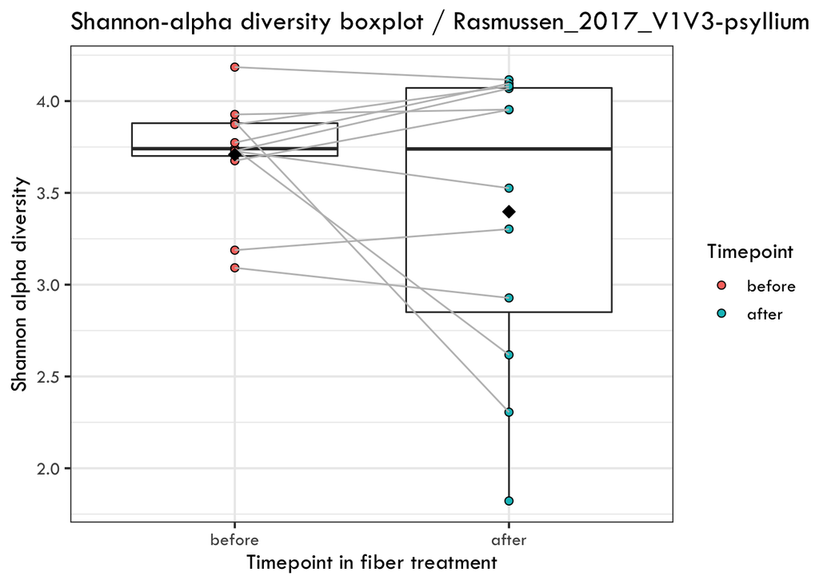

```r
ggplot (merged_alpha, aes(x= factor (timepoint, level= c("before","after")), y=Shannon)) +
  geom_boxplot() +
  geom_point(shape=21, size=2, (aes(fill = timepoint))) +
  scale_fill_hue(limits = c ("before","after")) +
  geom_line(aes(group = `subject_id`), color="grey") +
  labs(title = "Shannon-alpha diversity boxplot / Rasmussen_2017_V1V3-psyllium", x= "Timepoint in fiber treatment", y= "Shannon alpha diversity", fill="Timepoint") +
  theme_bw (base_family = "Tw Cen MT", base_size = 14) +
  stat_summary(fun = mean, geom = "point", shape=23, size=2.5, fill="black")
```

#### Save figure:

```r
ggsave("Figures/shannon_box.ALL.png", width = 7, height = 5)
```

##### Calculate means of both timepoints of Shannon with aggregate program https://r-coder.com/aggregate-r/ :

```r
means.shannon <- aggregate(merged_alpha$Shannon, list(merged_alpha$timepoint), mean)
means.shannon
```

```
#>   Group.1        x
#> 1   after 3.397399
#> 2  before 3.708733
```

#### Visualization Simpson by all timepoints:

##### Create a boxplot - Simpson:

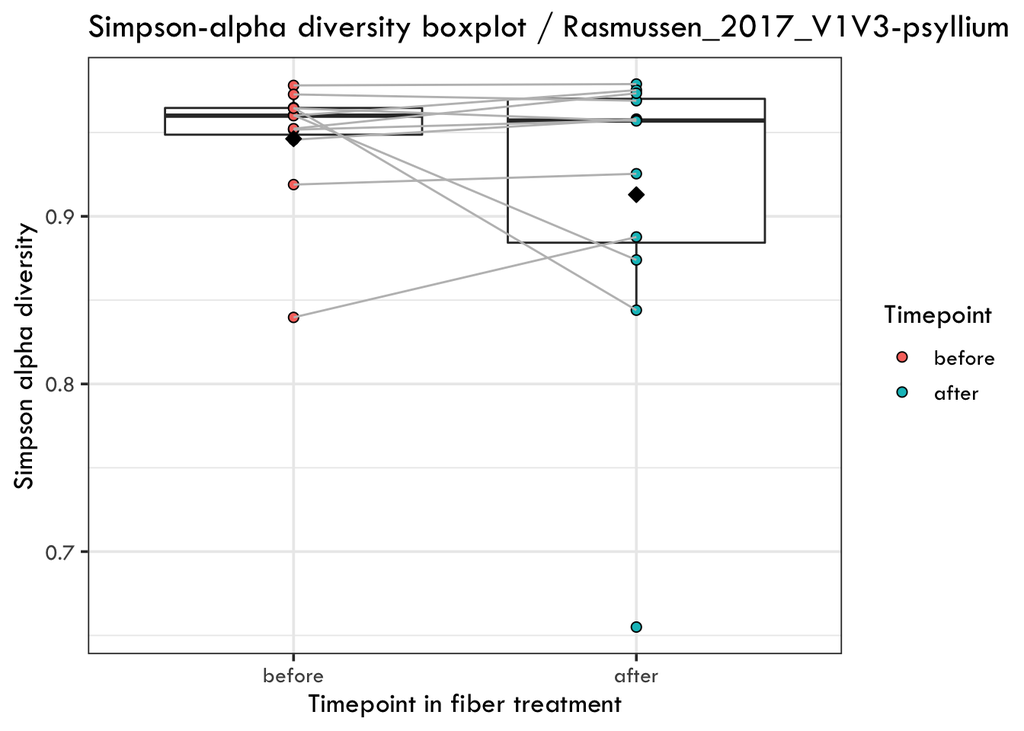

```r
ggplot (merged_alpha, aes(x= factor (timepoint, level= c("before","after")), y=Simpson)) +
  geom_boxplot() +
  geom_point(shape=21, size=2, (aes(fill = timepoint))) +
  scale_fill_hue(limits = c ("before","after")) +
  geom_line(aes(group = `subject_id`), color="grey") +
  labs(title = "Simpson-alpha diversity boxplot / Rasmussen_2017_V1V3-psyllium", x= "Timepoint in fiber treatment", y= "Simpson alpha diversity", fill="Timepoint") +
  theme_bw (base_family = "Tw Cen MT", base_size = 14) +
  stat_summary(fun = mean, geom = "point", shape=23, size=2.5, fill="black")
```

#### Save figure:

```r
ggsave("Figures/simpson_box.ALL.png", width = 7, height = 5)
```

##### Calculate means of both timepoints of Simpson with aggregate program https://r-coder.com/aggregate-r/ :

```r
means.simpson <- aggregate(merged_alpha$Simpson, list(merged_alpha$timepoint), mean)
means.simpson
```

```
#>   Group.1         x
#> 1   after 0.9129190
#> 2  before 0.9462601
```

#### Visualization Shannon by 2 timepoints only: ONLY TWO TIMEPOINTS - THEREFORE THIS IS NOT NEEDED

##### Prepare dataframe to correct formatting for statistical testing:

```r
# Delete samples that do not have two timepoints:
pairs.only.all.alpha <- merged_alpha %>%
  filter(duplicated(`subject_id`) | duplicated(`subject_id`, fromLast=TRUE)) %>%
  arrange(`timepoint`,`subject_id`)


#Save file with only before and during subjects, any subjects that did not have all timepoints were deleted:
write.table(x = pairs.only.all.alpha, file = "Output_files/6.psyllium_alpha_metrics_merged_metadata_only_pairs.txt", sep = "\t", row.names = TRUE, col.names = NA)


#Sort the data by timepoint and subject-id:
paired_data_alpha <- pairs.only.all.alpha[order(pairs.only.all.alpha$subject_id, pairs.only.all.alpha$`timepoint`),]

#see sorted data:
head(paired_data_alpha)
```

```
#>      SampleID Richness  Shannon   Simpson             sampleid     study
#> 1  SRR5504432      105 4.080624 0.9734221 rasmussen_SRR5504432 rasmussen
#> 12 SRR5504444      106 3.872578 0.9522774 rasmussen_SRR5504444 rasmussen
#> 2  SRR5504431       96 3.953816 0.9689788 rasmussen_SRR5504431 rasmussen
#> 13 SRR5504443       86 3.927184 0.9727586 rasmussen_SRR5504443 rasmussen
#> 3  SRR5504430       46 2.305501 0.8440194 rasmussen_SRR5504430 rasmussen
#> 14 SRR5504442      103 3.886611 0.9647990 rasmussen_SRR5504442 rasmussen
#>      subject_id treatment timepoint timepoint_numeric timepoint_id
#> 1  rasmussen_11     fiber     after                 2      after_2
#> 12 rasmussen_11     fiber    before                 1     before_1
#> 2  rasmussen_13     fiber     after                 2      after_2
#> 13 rasmussen_13     fiber    before                 1     before_1
#> 3  rasmussen_19     fiber     after                 2      after_2
#> 14 rasmussen_19     fiber    before                 1     before_1
#>       sample_name fiber_type fiber_amount time_days number gender age
#> 1  rasmussen_11_2   psyllium          12g       84d     69     NA  NA
#> 12 rasmussen_11_1   psyllium          12g        0d     81     NA  NA
#> 2  rasmussen_13_2   psyllium          12g       84d     68     NA  NA
#> 13 rasmussen_13_1   psyllium          12g        0d     80     NA  NA
#> 3  rasmussen_19_2   psyllium          12g       84d     67     NA  NA
#> 14 rasmussen_19_1   psyllium          12g        0d     79     NA  NA
#>    sample-name-original subject_id2  sampleid2
#> 1              NTX011V3          11 SRR5504432
#> 12             NTX011V2          11 SRR5504444
#> 2              NTX013V3          13 SRR5504431
#> 13             NTX013V2          13 SRR5504443
#> 3              NTX019V3          19 SRR5504430
#> 14             NTX019V2          19 SRR5504442
```

##### Perform summary and statistics to compare alpha diversity metrics between the same subjects before and after fiber intervention:

```r
#Do summary of Shannon alpha metric:
summary(paired_data_alpha$timepoint)
```

```
#>  after before
#>     11     11
```

```r
summary(paired_data_alpha$`subject_id`~timepoint~Shannon)
```

```
#>  Length   Class    Mode
#>       3 formula    call
```

```r
#pairwise t-test Shannon:
pairwise_t_test_shannon<- t.test(Shannon~timepoint,paired=TRUE, data=paired_data_alpha, p.adjust.method = "bonferroni" )
pairwise_t_test_shannon
```

```
#>
#>  Paired t-test
#>
#> data:  Shannon by timepoint
#> t = -0.89551, df = 10, p-value = 0.3916
#> alternative hypothesis: true difference in means is not equal to 0
#> 95 percent confidence interval:
#>  -0.5863833  0.2501650
#> sample estimates:
#> mean of the differences
#>              -0.1681092
```

```r
#pairwise t-test Simpson:
summary(paired_data_alpha$`subject_id`~timepoint~Simpson)
```

```
#>  Length   Class    Mode
#>       3 formula    call
```

```r
pairwise_t_test_simpson<- t.test(Simpson~timepoint,paired=TRUE, data=paired_data_alpha, p.adjust.method = "bonferroni" )
pairwise_t_test_simpson
```

```
#>
#>  Paired t-test
#>
#> data:  Simpson by timepoint
#> t = -0.66639, df = 10, p-value = 0.5202
#> alternative hypothesis: true difference in means is not equal to 0
#> 95 percent confidence interval:
#>  -0.04297591  0.02318771
#> sample estimates:
#> mean of the differences
#>            -0.009894098
```

```r
#general linear model:
glm.test.shannon <- glm(Shannon~timepoint, data=paired_data_alpha, family = "gaussian")
glm.test.shannon
```

```
#>
#> Call:  glm(formula = Shannon ~ timepoint, family = "gaussian", data = paired_data_alpha)
#>
#> Coefficients:
#>     (Intercept)  timepointbefore
#>          3.5406           0.1681
#>
#> Degrees of Freedom: 21 Total (i.e. Null);  20 Residual
#> Null Deviance:       5.507
#> Residual Deviance: 5.351     AIC: 37.33
```

```r
#linear mixed model: https://ourcodingclub.github.io/tutorials/mixed-models/
#association between timepoint and the Shannon, we want to know if that association exists after controlling for the variation in subjetc_id.
library(lme4)
lm.test.shannon <- lmer(Shannon~timepoint + (1|`subject_id`), data = paired_data_alpha)
summary(lm.test.shannon)
```

```
#> Linear mixed model fit by REML ['lmerMod']
#> Formula: Shannon ~ timepoint + (1 | subject_id)
#>    Data: paired_data_alpha
#>
#> REML criterion at convergence: 34.4
#>
#> Scaled residuals:
#>      Min       1Q   Median       3Q      Max
#> -2.28660 -0.25257  0.03332  0.71989  0.95672
#>
#> Random effects:
#>  Groups     Name        Variance Std.Dev.
#>  subject_id (Intercept) 0.07375  0.2716
#>  Residual               0.19382  0.4403
#> Number of obs: 22, groups:  subject_id, 11
#>
#> Fixed effects:
#>                 Estimate Std. Error t value
#> (Intercept)       3.5406     0.1560  22.702
#> timepointbefore   0.1681     0.1877   0.896
#>
#> Correlation of Fixed Effects:
#>             (Intr)
#> timepontbfr -0.602
```

##### Looking at these plots and t-tests, there are a number of questions we want to ask: PENDING RESULTS

- Are before fiber samples more/less diverse than after fiber samples?
  - ANSWER: Based on the plots, it seems that alpha diversity slightly decreases
- Does diversity change after treatments?
  - ANSWER: Based on the mean alpha diversity metrics, it seems that after the intervention the diversity slighty decreases.
- Is the difference in microbiome richness between before and after fiber treatment statistically significant??
  - ANSWER: No, based on the paired t-tests for Shannon and Simpson alpha diversity metrics.

## _____________ Beta-Diversity Analysis________

DO NOT use rarefied data here because you can rarefy within the Bray-Curtis calculation:

#### Create your Bray-Curtis dissimilarities to use in NMDS ordination:

- Note: sample = is your rarefaction depth, which we are setting as the lowest reads in our dataset https://rdrr.io/cran/vegan/man/avgdist.html
- Default is Bray-Curtis calculated by vegdist()
- Transform data using square root to minimize influence of most abundant groups.
- avgdist=Averaged Subsampled Dissimilarity Matrices.The function computes the dissimilarity matrix of a dataset multiple times using vegdist while randomly subsampling the dataset each time. All of the subsampled iterations are then averaged (mean or median) to provide a distance matrix that represents the average of multiple subsampling iterations. We use median so as to discount any outlier subsamplings. https://cran.r-project.org/web/packages/vegan/vegan.pdf

```r
set.seed(2022) #reproducible results

bray.dist <- avgdist(SV.table_psyllium,
                     sample = 1197,
                     meanfun = median, transf = sqrt, iterations = 1000)
```

#### Next, run an NMDS, which is a form of ordination and can be used to visualize beta diversity in base R:

```r
set.seed(2022) #reproducible results
NMDS1 <- metaMDS(bray.dist, autotransform = FALSE, k = 2)
```

```
#> *** No convergence -- monoMDS stopping criteria:
#>     19: stress ratio > sratmax
#>      1: scale factor of the gradient < sfgrmin
```

```r
NMDS1
```

```
#>
#> Call:
#> metaMDS(comm = bray.dist, k = 2, autotransform = FALSE)
#>
#> global Multidimensional Scaling using monoMDS
#>
#> Data:     bray.dist
#> Distance: avgdist
#>
#> Dimensions: 2
#> Stress:     0.1602637
#> Stress type 1, weak ties
#> No convergent solutions - best solution after 20 tries
#> Scaling: centring, PC rotation
#> Species: scores missing
```

##### Store the first two columns as the x and y coordinates, so that they may be plotted:

```r
coordinates <- data.frame(NMDS1$points[,1:2])

#Save Bray-Curtis dissimilarity NMDS cordinates:
  write.table(x = coordinates, file = "Output_files/7.NMDS.coordinates.txt", sep = "\t", row.names = TRUE, col.names = NA)
```

##### Plot the coordinates data from NMDS with base R:

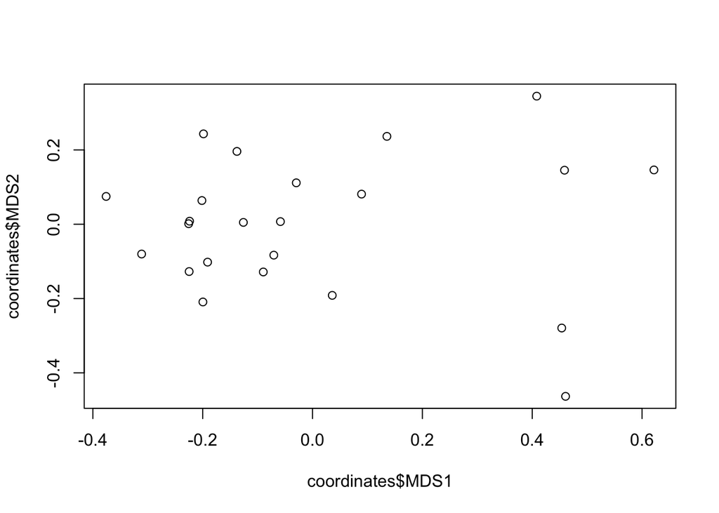

```r
plot(x = coordinates$MDS1, y = coordinates$MDS2)
```

##### To make a more sophisticated plot, merge the stress scores with the metadata file:

```r
nmds_plus_metadata <- merge(coordinates, metadata, by.x = "row.names", by.y = "sample_id_2")

#Save Bray-Curtis dissimilarity NMDS cordinates plus metadata:
  write.table(x = coordinates, file = "Output_files/8.NMDS.coordinates.metadata.txt", sep = "\t", row.names = TRUE, col.names = NA)
```

#### Build NMDS with timepoint as color:

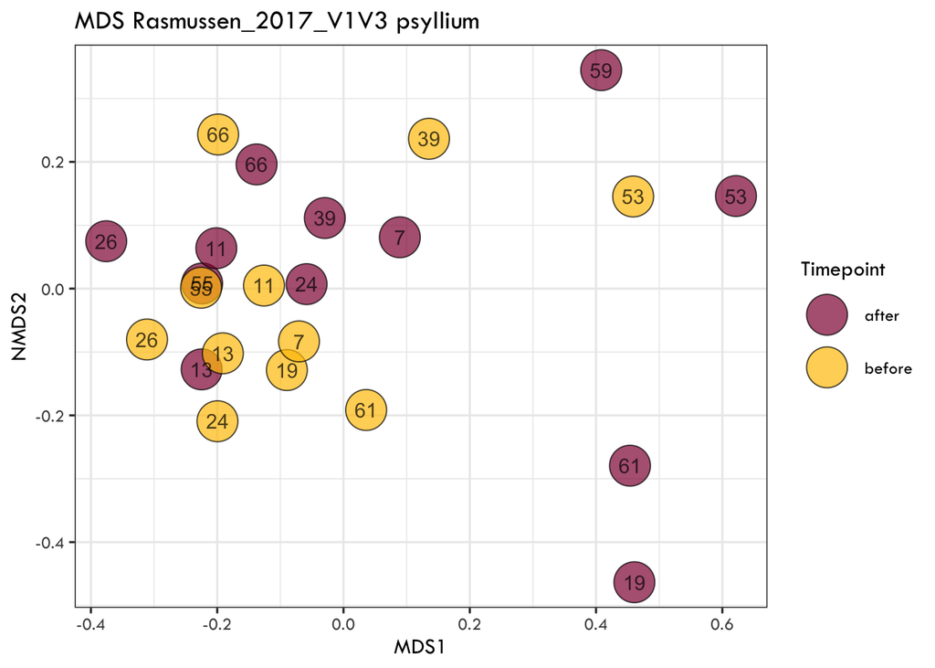

```r
  ggplot(data = nmds_plus_metadata) +
  aes(x = MDS1, y = MDS2, fill = as.factor(`timepoint`)) +
  geom_point(pch = 21, aes(fill = as.factor(`timepoint`)), size = 10, alpha = 0.7) +
  scale_fill_manual(values =c("#900C3F", "#FFC300")) +
  guides(color = F, fill = guide_legend(override.aes = list(shape = 21))) +
  geom_text(label = (nmds_plus_metadata$`subject_id2`), alpha = 0.7) +
labs(title = "MDS Rasmussen_2017_V1V3 psyllium", x= "MDS1", y= "NMDS2", fill="Timepoint") +
  theme_bw (base_family = "Tw Cen MT", base_size = 12)
```

#### Save figure:

```r
ggsave("Figures/NMDS.all.png", width = 7, height = 5)
```

#### To run statistical analyses, make averaged Bray-Curtis dissimilarity matrix:

```r
set.seed(2022) #reproducible results
  bray.dist.matrix <- as.data.frame(as.matrix(avgdist(SV.table_psyllium, sample = 1197, meanfun = median, transf = sqrt, iterations = 1000))) #default is Bray-Curtis calculated by vegdist()
```

#### Save Bray-Curtis dissimilarity matrix in a file:

```r
  write.table(x = bray.dist.matrix, file = "Output_files/9.psyllium_median_bray_curtis_sqrt_q1_single_rarefied_to_1197.txt", sep = "\t", row.names = TRUE, col.names = NA)
```

#### Confirm variables have been changed to factors in metadata file (if you have not done so already):

```r
class(metadata$`timepoint`)
```

```
#> [1] "factor"
```

```r
class(metadata$`subject_id`)
```

```
#> [1] "factor"
```

#### Remove from metadata the dropped sample because below rarefaction threshold:

```r
metadata <- metadata[!(metadata$sampleid2 %in% c('SRR5504436')), ]
```

#### Example 1,interaction subject X timepoint, by=terms assesses the significance for each term sequentially from first to last:

```r
set.seed(2022) #reproducible results
  PERMANOVA1 <- adonis2(bray.dist.matrix~`subject_id`*`timepoint`, data=metadata, method = "bray", by="terms",permutations = 999)
  PERMANOVA1
```

```
#> No residual component
#>
#> adonis2(formula = bray.dist.matrix ~ subject_id * timepoint, data = metadata, permutations = 999, method = "bray", by = "terms")
#>          Df SumOfSqs R2 F Pr(>F)
#> Model    22   7.9432  1
#> Residual  0   0.0000  0
#> Total    22   7.9432  1
```

```r
  #Save PERMANOVA:
write.table(PERMANOVA1, file = "Output_files/10.PERMANOVA_interaction_term.txt", sep = "\t", row.names = TRUE, col.names = NA)
```

#### Example 2, testing interaction subject X timepoint, ignoring order by=NULL assesses the overall significance of all terms together:

```r
set.seed(2022) #reproducible results
 PERMANOVA2 <- adonis2(bray.dist.matrix~`subject_id`*`timepoint`, data=metadata, method = "bray", by= NULL, permutations = 999)

  PERMANOVA2
```

```
#> No residual component
#>
#> adonis2(formula = bray.dist.matrix ~ subject_id * timepoint, data = metadata, permutations = 999, method = "bray", by = NULL)
#>          Df SumOfSqs R2 F Pr(>F)
#> Model    22   7.9432  1
#> Residual  0   0.0000  0
#> Total    22   7.9432  1
```

```r
  #Save PERMANOVA:
write.table(PERMANOVA2, file = "Output_files/11.PERMANOVA_interaction_null.txt", sep = "\t", row.names = TRUE, col.names = NA)
```

#### Example 3, not testing interaction subject + timepoint, by=terms assesses the significance for each term sequentially from first to last::

```r
set.seed(2022) #reproducible results
PERMANOVA3 <-  adonis2(bray.dist.matrix~`subject_id`+`timepoint`, data=metadata, method = "bray", by="terms",permutations = 999)

  PERMANOVA3
```

```
#> Permutation test for adonis under reduced model
#> Terms added sequentially (first to last)
#> Permutation: free
#> Number of permutations: 999
#>
#> adonis2(formula = bray.dist.matrix ~ subject_id + timepoint, data = metadata, permutations = 999, method = "bray", by = "terms")
#>            Df SumOfSqs      R2      F Pr(>F)
#> subject_id 11   6.0112 0.75678 3.1658  0.001 ***
#> timepoint   1   0.2058 0.02591 1.1921  0.197
#> Residual   10   1.7262 0.21732
#> Total      22   7.9432 1.00000
#> ---
#> Signif. codes:  0 '***' 0.001 '**' 0.01 '*' 0.05 '.' 0.1 ' ' 1
```

```r
  #Save PERMANOVA:
write.table(PERMANOVA3, file = "Output_files/12.PERMANOVA_NOinteraction_term.txt", sep = "\t", row.names = TRUE, col.names = NA)
```

#### Example 4, not testing interaction subject + timepoint, ignoring order by=NULL assesses the overall significance of all terms together:

```r
set.seed(2022) #reproducible results
PERMANOVA4 <-  adonis2(bray.dist.matrix~`subject_id`+`timepoint`, data=metadata, method = "bray", by=NULL,permutations = 999)

  PERMANOVA4
```

```
#> Permutation test for adonis under reduced model
#> Permutation: free
#> Number of permutations: 999
#>
#> adonis2(formula = bray.dist.matrix ~ subject_id + timepoint, data = metadata, permutations = 999, method = "bray", by = NULL)
#>          Df SumOfSqs      R2      F Pr(>F)
#> Model    12   6.2170 0.78268 3.0013  0.001 ***
#> Residual 10   1.7262 0.21732
#> Total    22   7.9432 1.00000
#> ---
#> Signif. codes:  0 '***' 0.001 '**' 0.01 '*' 0.05 '.' 0.1 ' ' 1
```

```r
  #Save PERMANOVA:
write.table(PERMANOVA4, file = "Output_files/13.PERMANOVA_NOinteraction_null.txt", sep = "\t", row.names = TRUE, col.names = NA)
```

#### Example 5, testing subject_id by itself:

```r
set.seed(2022) #reproducible results
  adonis2(bray.dist.matrix~`subject_id`, data=metadata, permutations = 999, method = "bray")
```

```
#> Permutation test for adonis under reduced model
#> Terms added sequentially (first to last)
#> Permutation: free
#> Number of permutations: 999
#>
#> adonis2(formula = bray.dist.matrix ~ subject_id, data = metadata, permutations = 999, method = "bray")
#>            Df SumOfSqs      R2      F Pr(>F)
#> subject_id 11   6.0112 0.75678 3.1115  0.001 ***
#> Residual   11   1.9319 0.24322
#> Total      22   7.9432 1.00000
#> ---
#> Signif. codes:  0 '***' 0.001 '**' 0.01 '*' 0.05 '.' 0.1 ' ' 1
```

- subject_id = YES significant, explaining 76% of variance
- timepoint (before vs after) = NOT significant, explaining 2.6% of variance
- subject_id and timepoint interaction = could not be tested